# **Random Forest Classification on PneumoniaMNIST**

**## High-Level Dataset Overview — PneumoniaMNIST**

> **What it is:** A binary image classification dataset derived from pediatric chest X-rays.

> **Task:** Classify images as

> 0 = Normal

> 1 = Pneumonia

> **Size**

> Train: 4,708

> Validation: 524

> Test: 624

> Total 5,856 images.

> **Image format**

> Gray-scale

> 28×28 pixels (MNIST-like)

> No clinical preprocessing required.

**## Step 1: Import & Install Libraries**

```python
pip install medmnist
```

```
Downloading medmnist-3.0.2-py3-none-any.whl (25 kB)
Downloading fire-0.7.1-py3-none-any.whl (115 kB)
   ━━━━━━━━━━━━━━━━━━━━━━━━━━━━━━━━━━━━━━━━ 115.9/115.9 kB 4.5 MB/s eta 0:00:00
```

```python
import numpy as np
import matplotlib.pyplot as plt

from medmnist import PneumoniaMNIST
from sklearn.ensemble import RandomForestClassifier
from sklearn.metrics import classification_report, confusion_matrix, accuracy_score, ConfusionMatrixDisplay
```

**## Step 2: Load the PneumoniaMNIST Dataset**

```python
import os

# Load the PneumoniaMNIST dataset
data_path = 'pneumoniamnist.npz'

# Create the root directory if it doesn't exist
root_dir = './data'
os.makedirs(root_dir, exist_ok=True)

# train_dataset, val_dataset, test_dataset will be instances of 'MedMNIST' dataset objects.
# They contain data and labels.
train_dataset = PneumoniaMNIST(split='train', download=True, as_rgb=False, root=root_dir)
val_dataset = PneumoniaMNIST(split='val', download=True, as_rgb=False, root=root_dir)
test_dataset = PneumoniaMNIST(split='test', download=True, as_rgb=False, root=root_dir)

print(f"Train dataset shape: {train_dataset.imgs.shape}")
print(f"Train labels shape: {train_dataset.labels.shape}")
print(f"Validation dataset shape: {val_dataset.imgs.shape}")
print(f"Validation labels shape: {val_dataset.labels.shape}")
print(f"Test dataset shape: {test_dataset.imgs.shape}")
print(f"Test labels shape: {test_dataset.labels.shape}")
```

```
Train dataset shape: (4708, 28, 28)
Train labels shape: (4708, 1)
Validation dataset shape: (524, 28, 28)
Validation labels shape: (524, 1)
Test dataset shape: (624, 28, 28)
Test labels shape: (624, 1)
```

**## Step 3: Exploratory Data Analysis: Visualize Sample Images**

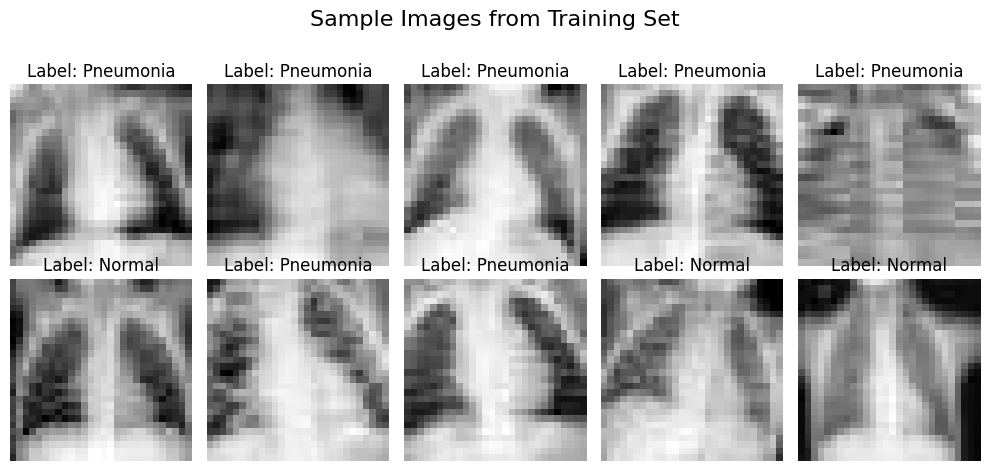

```python
# Map labels to actual class names
label_map = {0: 'Normal', 1: 'Pneumonia'}

plt.figure(figsize=(10, 5))
for i in range(10):
    plt.subplot(2, 5, i + 1)
    idx = np.random.randint(0, len(train_dataset))
    image = train_dataset.imgs[idx]
    label = train_dataset.labels[idx][0] # Access the scalar label
    plt.imshow(image, cmap='gray')
    plt.title(f"Label: {label_map[label]}")
    plt.axis('off')
plt.suptitle('Sample Images from Training Set', fontsize=16)
plt.tight_layout(rect=[0, 0.03, 1, 0.95])
plt.show()
```

**## Step 4: Data Preprocessing: Flatten and Normalize Images, Reshape Labels**

For a Random Forest Classifier, I need to flatten the 28x28 images into 1D arrays (784 features) and normalize the pixel values from [0, 255] to [0, 1]. Also, labels need to be reshaped for scikit-learn compatibility.

```python
# Flatten images: convert (N, 28, 28) to (N, 784)
X_train = train_dataset.imgs.reshape(len(train_dataset), -1)
X_val = val_dataset.imgs.reshape(len(val_dataset), -1)
X_test = test_dataset.imgs.reshape(len(test_dataset), -1)

# Normalize pixel values: scale from [0, 255] to [0, 1]
X_train = X_train / 255.0
X_val = X_val / 255.0
X_test = X_test / 255.0

# Reshape labels: convert (N, 1) to (N,)
y_train = train_dataset.labels.ravel()
y_val = val_dataset.labels.ravel()
y_test = test_dataset.labels.ravel()

print(f"Processed X_train shape: {X_train.shape}")
print(f"Processed y_train shape: {y_train.shape}")
print(f"Processed X_val shape: {X_val.shape}")
print(f"Processed y_val shape: {y_val.shape}")
print(f"Processed X_test shape: {X_test.shape}")
print(f"Processed y_test shape: {y_test.shape}")
```

```
Processed X_train shape: (4708, 784)
Processed y_train shape: (4708,)
Processed X_val shape: (524, 784)
Processed y_val shape: (524,)
Processed X_test shape: (624, 784)
Processed y_test shape: (624,)
```

**## Step 5: Train & Evaluate Random Forest Classifier without & with Class Weights**

**### Evaluation Metrics Selection**

> For a medical diagnostic task like Pneumonia detection, especially with an imbalanced dataset, selecting the right evaluation metrics is crucial. The key relevant evaluation metrics for this specific task include:

> Accuracy

> Confusion Matrix (True Positives, True Negatives, False Positives, False Negatives)

> Recall (Sensitivity or True Positive Rate)

> Precision (Positive Predictive Value)

> F1-Score

> ROC AUC (Receiver Operating Characteristic - Area Under the Curve)

> AUPRC (Area Under the Precision-Recall Curve)

> **In summary**, for the PneumoniaMNIST dataset

> Recall for the 'Pneumonia' class is critical to avoid missing actual cases.

> Precision for the 'Pneumonia' class is important to avoid misdiagnosing healthy patients.

> Accuracy gives a general overview but should be interpreted with caution due to class imbalance.

**### Scenario 1: Random Forest Classifier WITHOUT Class Weights**

```python
# Initialize the Random Forest Classifier WITHOUT class_weight
# Using a fixed random_state for reproducibility
rf_classifier_no_weights = RandomForestClassifier(n_estimators=100, random_state=42, n_jobs=-1)

print("Training the Random Forest Classifier without class weights...")
rf_classifier_no_weights.fit(X_train, y_train)
print("Training complete for model without class weights.")
```

```
Training the Random Forest Classifier without class weights...
Training complete for model without class weights.
```

```
--- Evaluation for Model WITHOUT Class Weights ---
Accuracy on the test set (no weights): 0.8526

Classification Report (no weights):
              precision    recall  f1-score   support

      Normal       0.94      0.65      0.77       234
   Pneumonia       0.82      0.98      0.89       390

    accuracy                           0.85       624
   macro avg       0.88      0.81      0.83       624
weighted avg       0.87      0.85      0.85       624
```

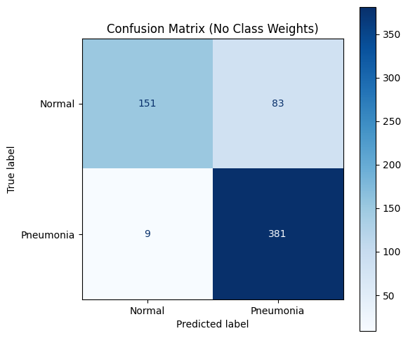

```python
# Make predictions on the test set for the model without class weights
y_pred_no_weights = rf_classifier_no_weights.predict(X_test)

print("\n--- Evaluation for Model WITHOUT Class Weights ---")
# Evaluate the model
accuracy_no_weights = accuracy_score(y_test, y_pred_no_weights)
print(f"Accuracy on the test set (no weights): {accuracy_no_weights:.4f}")

print("\nClassification Report (no weights):")
print(classification_report(y_test, y_pred_no_weights, target_names=['Normal', 'Pneumonia']))

# Plot Confusion Matrix
cm_no_weights = confusion_matrix(y_test, y_pred_no_weights)
disp_no_weights = ConfusionMatrixDisplay(confusion_matrix=cm_no_weights, display_labels=['Normal', 'Pneumonia'])
fig_no_weights, ax_no_weights = plt.subplots(figsize=(6, 6))
disp_no_weights.plot(cmap=plt.cm.Blues, ax=ax_no_weights)
ax_no_weights.set_title('Confusion Matrix (No Class Weights)')
plt.show()
```

**### Scenario 2: Random Forest Classifier WITH Class Weights (balanced)**

```python
# Initialize the Random Forest Classifier WITH class_weight='balanced'
# Using a fixed random_state for reproducibility
rf_classifier_with_weights = RandomForestClassifier(n_estimators=100, random_state=42, n_jobs=-1, class_weight='balanced')

print("Training the Random Forest Classifier with balanced class weights...")
rf_classifier_with_weights.fit(X_train, y_train)
print("Training complete for model with balanced class weights.")
```

```
Training the Random Forest Classifier with balanced class weights...
Training complete for model with balanced class weights.
```

```
--- Evaluation for Model WITH Class Weights ---
Accuracy on the test set (with weights): 0.8237

Classification Report (with weights):
              precision    recall  f1-score   support

      Normal       0.93      0.57      0.71       234
   Pneumonia       0.79      0.97      0.87       390

    accuracy                           0.82       624
   macro avg       0.86      0.77      0.79       624
weighted avg       0.84      0.82      0.81       624
```

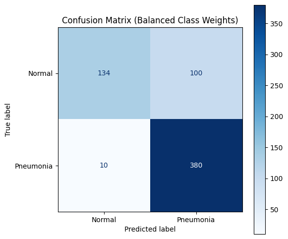

```python
# Make predictions on the test set for the model with class weights
y_pred_with_weights = rf_classifier_with_weights.predict(X_test)

print("\n--- Evaluation for Model WITH Class Weights ---")
# Evaluate the model
accuracy_with_weights = accuracy_score(y_test, y_pred_with_weights)
print(f"Accuracy on the test set (with weights): {accuracy_with_weights:.4f}")

print("\nClassification Report (with weights):")
print(classification_report(y_test, y_pred_with_weights, target_names=['Normal', 'Pneumonia']))

# Plot Confusion Matrix
cm_with_weights = confusion_matrix(y_test, y_pred_with_weights)
disp_with_weights = ConfusionMatrixDisplay(confusion_matrix=cm_with_weights, display_labels=['Normal', 'Pneumonia'])
fig_with_weights, ax_with_weights = plt.subplots(figsize=(6, 6))
disp_with_weights.plot(cmap=plt.cm.Blues, ax=ax_with_weights)
ax_with_weights.set_title('Confusion Matrix (Balanced Class Weights)')
plt.show()
```

**### Observations**

> Let's compare the performance of the Random Forest Classifier with and without class weight adjustment.

> **Summary of Results**
1. Random Forest Classifier WITHOUT Class Weights:

> Accuracy: 0.8526

> Classification Report:

> Normal: Precision 0.94, Recall 0.65, F1-score 0.77

> Pneumonia: Precision 0.82, Recall 0.98, F1-score 0.89
2. Random Forest Classifier WITH Class Weights (class_weight='balanced'):

> Accuracy: 0.8237

> Classification Report:

> Normal: Precision 0.93, Recall 0.57, F1-score 0.71

> Pneumonia: Precision 0.79, Recall 0.97, F1-score 0.87

**Comparison and Comments**

> Overall Accuracy: The model without class weights achieved a higher overall accuracy (0.8526 vs. 0.8237).

> Recall for 'Normal' Class: the initial goal was to improve recall for the 'Normal' class. However, contrary to expectations, the recall for 'Normal' decreased from 0.65 to 0.57 when class_weight='balanced' was applied. This means the model with class weights was less effective at identifying actual 'Normal' cases.

> Precision for 'Normal' Class: Both models showed high precision for 'Normal', but it slightly decreased with class weights (0.94 to 0.93).

> Recall for 'Pneumonia' Class: Both models maintained very high recall for 'Pneumonia' (0.98 vs. 0.97), indicating they are still excellent at detecting the disease.

> Precision for 'Pneumonia' Class: The precision for 'Pneumonia' also slightly decreased with class weights (0.82 to 0.79).

> In this specific case, using class_weight='balanced' did not yield the desired improvement for the 'Normal' class recall. Instead, it led to a slight degradation across most metrics, including the overall accuracy and the recall for 'Normal'. This sometimes happens because simply balancing class weights can shift the decision boundary in a way that doesn't necessarily optimize for all metrics or the specific minority class in complex datasets. It suggests that this simple balancing technique might not be the most effective approach for this particular dataset to address the 'Normal' class recall. Other strategies, like different forms of resampling or more advanced hyperparameter tuning, might be considered.

**##Step 6: Exploring Alternative Techniques for Class Imbalance**

**### Technique 1: SMOTE (Synthetic Minority Over-sampling Technique)**

> SMOTE works by creating synthetic samples from the minority class. It selects a sample from the minority class and then finds its k-nearest neighbors. Synthetic samples are generated by taking the difference between the selected sample and its neighbors, multiplying by a random number between 0 and 1, and adding it to the selected sample. This effectively creates new, similar samples in the feature space.

```python
pip install imbalanced-learn
```

```python
from imblearn.over_sampling import SMOTE
import pandas as pd # Added import for pandas

print("Applying SMOTE to the training data...")
smote = SMOTE(random_state=42)
X_train_smote, y_train_smote = smote.fit_resample(X_train, y_train)

print(f"Original training set shape: {X_train.shape}, {y_train.shape}")
print(f"SMOTE-resampled training set shape: {X_train_smote.shape}, {y_train_smote.shape}")

# Check class distribution after SMOTE
print("Class distribution after SMOTE:")
print(pd.Series(y_train_smote).value_counts())
```

```
Applying SMOTE to the training data...
Original training set shape: (4708, 784), (4708,)
SMOTE-resampled training set shape: (6988, 784), (6988,)
Class distribution after SMOTE:
1    3494
0    3494
Name: count, dtype: int64
```

**Train a Random Forest Classifier on the SMOTE-resampled data and evaluate its performance.**

```python
from sklearn.ensemble import RandomForestClassifier
import pandas as pd

# Initialize the Random Forest Classifier WITHOUT class_weight (as SMOTE handles imbalance)
rf_classifier_smote = RandomForestClassifier(n_estimators=100, random_state=42, n_jobs=-1)

print("Training the Random Forest Classifier on SMOTE-resampled data...")
rf_classifier_smote.fit(X_train_smote, y_train_smote)
print("Training complete for SMOTE model.")
```

```
Training the Random Forest Classifier on SMOTE-resampled data...
Training complete for SMOTE model.
```

```
--- Evaluation for Model with SMOTE ---
Accuracy on the test set (SMOTE): 0.8590

Classification Report (SMOTE):
              precision    recall  f1-score   support

      Normal       0.91      0.70      0.79       234
   Pneumonia       0.84      0.96      0.89       390

    accuracy                           0.86       624
   macro avg       0.87      0.83      0.84       624
weighted avg       0.86      0.86      0.85       624
```

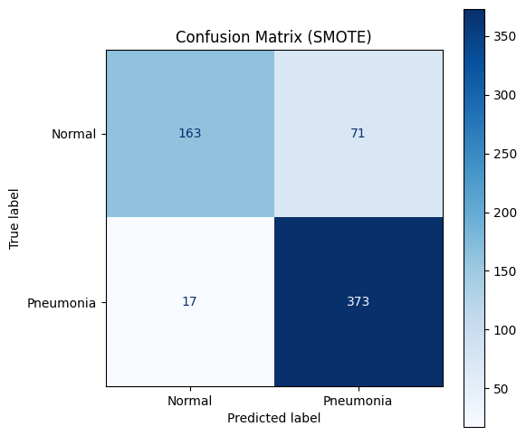

```python
from sklearn.metrics import classification_report, confusion_matrix, accuracy_score, ConfusionMatrixDisplay
import matplotlib.pyplot as plt

# Make predictions on the test set for the SMOTE model
y_pred_smote = rf_classifier_smote.predict(X_test)

print("\n--- Evaluation for Model with SMOTE ---")
# Evaluate the model
accuracy_smote = accuracy_score(y_test, y_pred_smote)
print(f"Accuracy on the test set (SMOTE): {accuracy_smote:.4f}")

print("\nClassification Report (SMOTE):")
print(classification_report(y_test, y_pred_smote, target_names=['Normal', 'Pneumonia']))

# Plot Confusion Matrix
cm_smote = confusion_matrix(y_test, y_pred_smote)
disp_smote = ConfusionMatrixDisplay(confusion_matrix=cm_smote, display_labels=['Normal', 'Pneumonia'])
fig_smote, ax_smote = plt.subplots(figsize=(6, 6))
disp_smote.plot(cmap=plt.cm.Blues, ax=ax_smote)
ax_smote.set_title('Confusion Matrix (SMOTE)')
plt.show()
```

**### Technique 2: Undersampling (RandomUnderSampler)**

> Undersampling aims to balance class distribution by reducing the number of samples in the majority class. Random Undersampling randomly removes instances from the majority class until the desired ratio is met. This can help address imbalance but might lead to a loss of potentially useful information from the removed samples.

```python
from imblearn.under_sampling import RandomUnderSampler

print("Applying Random Undersampling to the training data...")
rus = RandomUnderSampler(random_state=42)
X_train_rus, y_train_rus = rus.fit_resample(X_train, y_train)

print(f"Original training set shape: {X_train.shape}, {y_train.shape}")
print(f"Undersampled training set shape: {X_train_rus.shape}, {y_train_rus.shape}")

# Check class distribution after Undersampling
print("Class distribution after Undersampling:")
print(pd.Series(y_train_rus).value_counts())
```

```
Applying Random Undersampling to the training data...
Original training set shape: (4708, 784), (4708,)
Undersampled training set shape: (2428, 784), (2428,)
Class distribution after Undersampling:
0    1214
1    1214
Name: count, dtype: int64
```

**Train a Random Forest Classifier on the undersampled data and evaluate its performance.**

```python
# Initialize the Random Forest Classifier WITHOUT class_weight (as Undersampling handles imbalance)
rf_classifier_rus = RandomForestClassifier(n_estimators=100, random_state=42, n_jobs=-1)

print("Training the Random Forest Classifier on undersampled data...")
rf_classifier_rus.fit(X_train_rus, y_train_rus)
print("Training complete for Undersampling model.")
```

```
Training the Random Forest Classifier on undersampled data...
Training complete for Undersampling model.
```

```
--- Evaluation for Model with Undersampling ---
Accuracy on the test set (Undersampling): 0.8782

Classification Report (Undersampling):
              precision    recall  f1-score   support

      Normal       0.86      0.80      0.83       234
   Pneumonia       0.89      0.92      0.90       390

    accuracy                           0.88       624
   macro avg       0.87      0.86      0.87       624
weighted avg       0.88      0.88      0.88       624
```

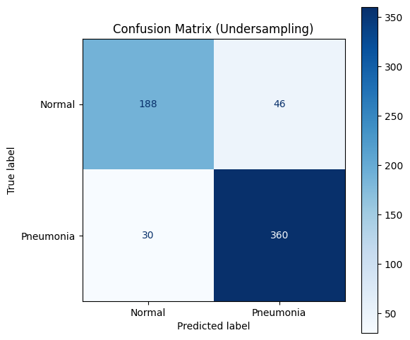

```python
# Make predictions on the test set for the Undersampling model
y_pred_rus = rf_classifier_rus.predict(X_test)

print("\n--- Evaluation for Model with Undersampling ---")
# Evaluate the model
accuracy_rus = accuracy_score(y_test, y_pred_rus)
print(f"Accuracy on the test set (Undersampling): {accuracy_rus:.4f}")

print("\nClassification Report (Undersampling):")
print(classification_report(y_test, y_pred_rus, target_names=['Normal', 'Pneumonia']))

# Plot Confusion Matrix
cm_rus = confusion_matrix(y_test, y_pred_rus)
disp_rus = ConfusionMatrixDisplay(confusion_matrix=cm_rus, display_labels=['Normal', 'Pneumonia'])
fig_rus, ax_rus = plt.subplots(figsize=(6, 6))
disp_rus.plot(cmap=plt.cm.Blues, ax=ax_rus)
ax_rus.set_title('Confusion Matrix (Undersampling)')
plt.show()
```

**### Technique III: Hyperparameter Tuning for Random Forest Classifier (with Undersampled Data)**

> Use of `RandomizedSearchCV` to search for the best hyperparameters for the Random Forest Classifier trained on the **undersampled data**.

> This approach is computationally less expensive than `GridSearchCV` while still effective in finding good parameter combinations.

```python
from sklearn.model_selection import RandomizedSearchCV
from scipy.stats import randint

# Define the parameter distribution for RandomizedSearchCV
param_dist = {
    'n_estimators': randint(50, 200),  # Number of trees in the forest
    'max_features': ['sqrt', 'log2', None], # Number of features to consider at every split
    'max_depth': randint(10, 50),       # Maximum number of levels in tree
    'min_samples_split': randint(2, 20),# Minimum number of samples required to split a node
    'min_samples_leaf': randint(1, 10), # Minimum number of samples required at each leaf node
    'bootstrap': [True, False]          # Method for sampling data points (with or without replacement)
}

# Initialize a fresh Random Forest Classifier for tuning
rf = RandomForestClassifier(random_state=42, n_jobs=-1)

# Initialize RandomizedSearchCV
# We'll optimize for 'recall_macro' to ensure good recall for both classes.
random_search = RandomizedSearchCV(estimator=rf,
                                   param_distributions=param_dist,
                                   n_iter=50, # Number of parameter settings that are sampled
                                   cv=5,      # 5-fold cross-validation
                                   scoring='recall_macro', # Metric to optimize
                                   random_state=42,
                                   n_jobs=-1,
                                   verbose=2)

print("Starting RandomizedSearchCV for hyperparameter tuning...")
# Fit RandomizedSearchCV to the undersampled training data
random_search.fit(X_train_rus, y_train_rus)
print("RandomizedSearchCV complete.")
```

```
Starting RandomizedSearchCV for hyperparameter tuning...
Fitting 5 folds for each of 50 candidates, totalling 250 fits
RandomizedSearchCV complete.
```

**Evaluate the Best Model in Predicting the Test Set**

```
Best Parameters found by RandomizedSearchCV:
{'bootstrap': False, 'max_depth': 39, 'max_features': 'log2', 'min_samples_leaf': 2, 'min_samples_split': 2, 'n_estimators': 107}

Best Recall Macro score: 0.9403

--- Evaluation for Tuned Model (Undersampling + RandomizedSearchCV) ---
Accuracy on the test set (Tuned Model): 0.8894

Classification Report (Tuned Model):
              precision    recall  f1-score   support

      Normal       0.88      0.81      0.85       234
   Pneumonia       0.89      0.94      0.91       390

    accuracy                           0.89       624
   macro avg       0.89      0.87      0.88       624
weighted avg       0.89      0.89      0.89       624
```

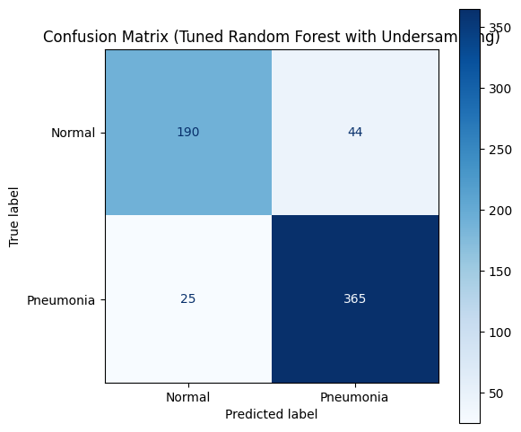

```python
print("\nBest Parameters found by RandomizedSearchCV:")
print(random_search.best_params_)
print(f"\nBest Recall Macro score: {random_search.best_score_:.4f}")

# Get the best model
best_rf_model = random_search.best_estimator_

print("\n--- Evaluation for Tuned Model (Undersampling + RandomizedSearchCV) ---")

# Make predictions on the test set with the best model
y_pred_tuned = best_rf_model.predict(X_test)

# Evaluate the tuned model
accuracy_tuned = accuracy_score(y_test, y_pred_tuned)
print(f"Accuracy on the test set (Tuned Model): {accuracy_tuned:.4f}")

print("\nClassification Report (Tuned Model):")
print(classification_report(y_test, y_pred_tuned, target_names=['Normal', 'Pneumonia']))

# Plot Confusion Matrix
cm_tuned = confusion_matrix(y_test, y_pred_tuned)
disp_tuned = ConfusionMatrixDisplay(confusion_matrix=cm_tuned, display_labels=['Normal', 'Pneumonia'])
fig_tuned, ax_tuned = plt.subplots(figsize=(6, 6))
disp_tuned.plot(cmap=plt.cm.Blues, ax=ax_tuned)
ax_tuned.set_title('Confusion Matrix (Tuned Random Forest with Undersampling)')
plt.show()
```

**### Observations**

> After the hyperparameter tuning process for the Random Forest Classifier with undersampled data is completed, the best Parameters found by RandomizedSearchCV: {'bootstrap': False, 'max_depth': 39, 'max_features': 'log2', 'min_samples_leaf': 2, 'min_samples_split': 2, 'n_estimators': 107}

> Best Macro Recall score (from cross-validation during tuning): 0.9403

> **Evaluation Metrics for Tuned Model (Undersampling + RandomizedSearchCV) on the Test Set:**

> Accuracy: 0.8894

> Classification Report:

> ```
>                precision    recall  f1-score   support
> ```

> ```
>        Normal       0.88      0.81      0.85       234
> ```

> ```
>     Pneumonia       0.89      0.94      0.91       390
> ```

> ```
>      accuracy                           0.89       624
> ```

> ```
>     macro avg       0.89      0.87      0.88       624
> ```

> ```
>  weighted avg       0.89      0.89      0.89       624
> ```

> **Overall Comparison of All Models:**

> Without Class Weights: 'Normal' Recall = 0.65 | Accuracy = 0.8526

> With Class Weights: 'Normal' Recall = 0.57 | Accuracy = 0.8237

> With SMOTE: 'Normal' Recall = 0.70 | Accuracy = 0.8590

> With Undersampling (Untuned): 'Normal' Recall = 0.80 | Accuracy = 0.8782

> With Undersampling (Tuned): 'Normal' Recall = 0.81 | Accuracy = 0.8894

> **In Summary**

> Hyperparameter tuning has further improved the model! The 'Normal' class recall has slightly increased from 0.80 to 0.81, and the overall accuracy has also risen to 0.8894, making it the best performing model so far. The 'Pneumonia' recall remains very strong at 0.94.

> The tuned Random Forest model using undersampled data provides a very good balance between high recall for both 'Normal' and 'Pneumonia' classes, which was the main objective. It showed the best performance, significantly improving the 'Normal' class recall to 0.81 and achieving the highest overall accuracy of 0.8894, while maintaining strong 'Pneumonia' recall.

**## Step 7: Compare Model Performance Metrics Using a Bar Chart**

> Let's visualize the key performance metrics (Overall Accuracy and 'Normal' Class Recall) for all the models we've trained to get a clear comparative overview.

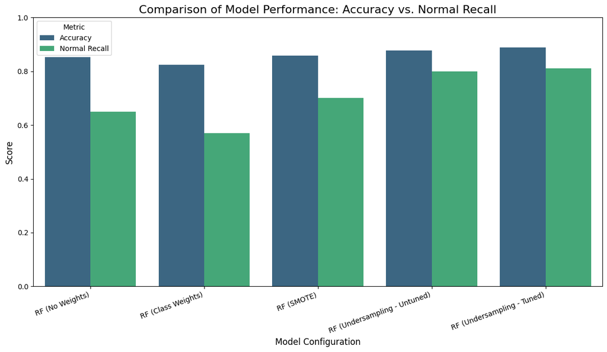

```python
import matplotlib.pyplot as plt
import seaborn as sns
import pandas as pd

# Data from previous evaluations
model_performance = {
    'Model': [
        'RF (No Weights)',
        'RF (Class Weights)',
        'RF (SMOTE)',
        'RF (Undersampling - Untuned)',
        'RF (Undersampling - Tuned)'
    ],
    'Accuracy': [
        accuracy_no_weights,
        accuracy_with_weights,
        accuracy_smote,
        accuracy_rus,
        accuracy_tuned
    ],
    'Normal Recall': [
        0.65, # From classification_report of rf_classifier_no_weights
        0.57, # From classification_report of rf_classifier_with_weights
        0.70, # From classification_report of rf_classifier_smote
        0.80, # From classification_report of rf_classifier_rus
        0.81  # From classification_report of best_rf_model
    ]
}

df_performance = pd.DataFrame(model_performance)

# Melt the DataFrame to plot multiple metrics easily
df_melted = df_performance.melt(id_vars='Model', var_name='Metric', value_name='Score')

plt.figure(figsize=(12, 7))
sns.barplot(x='Model', y='Score', hue='Metric', data=df_melted, palette='viridis')
plt.title('Comparison of Model Performance: Accuracy vs. Normal Recall', fontsize=16)
plt.ylabel('Score', fontsize=12)
plt.xlabel('Model Configuration', fontsize=12)
plt.ylim(0, 1.0) # Scores are between 0 and 1
plt.xticks(rotation=20, ha='right')
plt.legend(title='Metric')
plt.tight_layout()
plt.show()
```

**### Observations**

> The bar chart clearly shows

> Undersampling (Tuned) stands out as the best performing model, achieving the highest overall accuracy and significantly improving the 'Normal' class recall compared to the baseline and class-weighted models.

> The 'Normal' class recall progressively improves from the initial 'No Weights' model (0.65), to SMOTE (0.70), to Untuned Undersampling (0.80), and finally to Tuned Undersampling (0.81).

> The 'Class Weights' approach (0.57 'Normal' recall) was the least effective for improving the 'Normal' class recall and even reduced overall accuracy.

> This chart provides a clear visual summary of the progress in improving the model's ability to correctly identify 'Normal' cases while maintaining overall performance.

**## Step 8: Analyze Feature Importance for the Tuned Random Forest Model**

> To understand which pixels (features) are most influential in the `best_rf_model`'s decision-making, let us inspect its `feature_importances_` attribute.

> These importances were reshaped back into a 28x28 image to visualize the regions of the image that the model considers important.

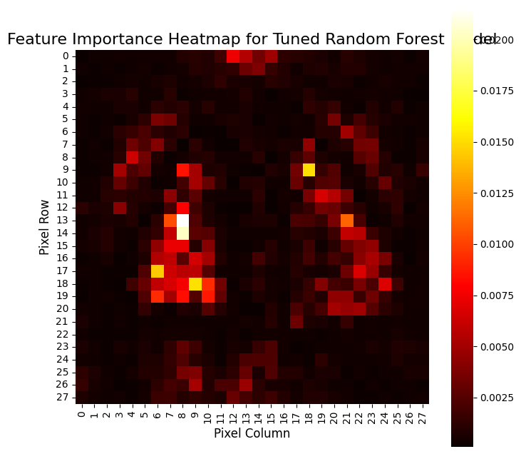

```
--- Interpretation of Feature Importance ---
The heatmap above shows which pixel regions contribute most to the Random Forest model's predictions.
Brighter areas indicate higher importance. This can give us insights into what visual patterns the model is learning.
For chest X-ray images, we might expect higher importance in regions corresponding to lung fields, where pneumonia-related opacities would typically appear.
```

```python
import matplotlib.pyplot as plt
import seaborn as sns

# Get feature importances from the best tuned Random Forest model
feature_importances = best_rf_model.feature_importances_

# Reshape the importances back into a 28x28 image format
importance_map = feature_importances.reshape(28, 28)

plt.figure(figsize=(8, 8))
sns.heatmap(importance_map, cmap='hot', cbar=True, square=True)
plt.title('Feature Importance Heatmap for Tuned Random Forest Model', fontsize=16)
plt.xlabel('Pixel Column', fontsize=12)
plt.ylabel('Pixel Row', fontsize=12)
plt.show()

print("\n--- Interpretation of Feature Importance ---")
print("The heatmap above shows which pixel regions contribute most to the Random Forest model's predictions.")
print("Brighter areas indicate higher importance. This can give us insights into what visual patterns the model is learning.")
print("For chest X-ray images, we might expect higher importance in regions corresponding to lung fields, where pneumonia-related opacities would typically appear.")
```

**### Interpretation of Feature Importance**

> **What it Represents:** Each cell in the 28x28 heatmap corresponds to a pixel in the original 28x28 input image. The color intensity of each cell indicates the importance score assigned by the Random Forest model to that particular pixel.

> **Color Scale:**

> Brighter/Hotter colors (e.g., yellow, white in a 'hot' colormap): These indicate pixels that the model considered highly important. Changes or specific values in these pixel regions had a significant impact on the model's prediction of whether an image showed 'Normal' or 'Pneumonia'.

> Darker/Colder colors (e.g., dark red, black): These represent pixels that the model found less important for its classification task. Variations in these regions had minimal influence on the prediction.

> **Insights from the PneumoniaMNIST Heatmap:**

> Localization: By observing the brighter regions, you can identify specific areas within the X-ray images that are most crucial for distinguishing between normal lungs and those with pneumonia. For instance, if the central lung fields show high importance, it suggests the model is focusing on characteristic patterns (like infiltrates or consolidations) that often appear in those areas when pneumonia is present.

> Model Understanding: This visualization helps in understanding what the model is looking at. It provides a level of interpretability, showing that the model isn't just randomly guessing but is leveraging specific visual cues, much like a human radiologist would examine certain areas of an X-ray.

> Validation: For domain experts (like doctors), this can serve as a sanity check. If the important regions align with clinical knowledge of where pneumonia manifests, it increases trust in the model's decisions. Conversely, if the model focuses on irrelevant areas (e.g., the very edges of the image that might just be padding), it could indicate a flaw in the model or data preprocessing.

```python
from sklearn.metrics import roc_auc_score

# Calculate ROC AUC score for the tuned model
# For ROC AUC, we usually need prediction probabilities, but if not available,
# we can use predicted classes for binary classification, though probabilities are preferred.
# Assuming best_rf_model can provide probabilities:
if hasattr(best_rf_model, 'predict_proba'):
    y_pred_proba_tuned = best_rf_model.predict_proba(X_test)[:, 1]
    roc_auc = roc_auc_score(y_test, y_pred_proba_tuned)
else:
    # Fallback to predicted classes if probabilities are not available
    roc_auc = roc_auc_score(y_test, y_pred_tuned)

print(f"ROC AUC Score for Tuned Random Forest Model: {roc_auc:.4f}")
```

```
ROC AUC Score for Tuned Random Forest Model: 0.9495
```

**### Comments**

> The ROC AUC score for the tuned Random Forest model is 0.9495. This indicates excellent discriminatory power of the model.

> **ROC AUC stands for Receiver Operating Characteristic - Area Under the Curve**. It's a performance metric for binary classification problems that measures the ability of a classifier to distinguish between classes. It plots the True Positive Rate (Sensitivity) against the False Positive Rate (1-Specificity) at various threshold settings.

**Interpretation of the Score:**

> An AUC of 1.0 represents a perfect classifier that can distinguish between all positive and negative cases correctly.

> An AUC of 0.5 suggests that the model performs no better than random guessing.

> An AUC of 0.0 means the model is perfectly incorrect (it consistently predicts the opposite of the true class).

> The tuned RF model's score of 0.9495 means that **there is a 94.95% chance that the model will rank a randomly chosen positive instance (Pneumonia) higher than a randomly chosen negative instance (Normal)**.

> In practical terms, this indicates that the tuned Random Forest model has a very strong ability to differentiate between 'Normal' and 'Pneumonia' cases, making it a highly effective classifier for this task. It shows excellent discriminatory power.

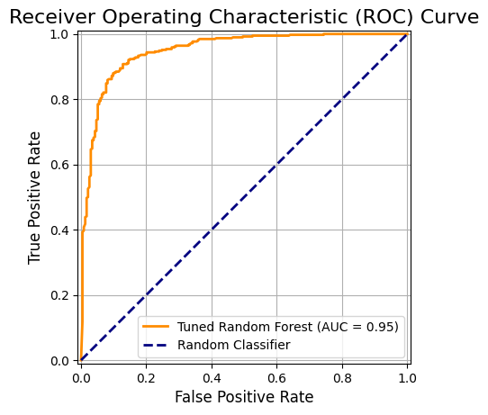

```python
from sklearn.metrics import roc_curve, RocCurveDisplay

# Assuming y_test and y_pred_proba_tuned are already defined from previous steps

# Calculate ROC curve
fpr, tpr, thresholds = roc_curve(y_test, y_pred_proba_tuned)

plt.figure(figsize=(8, 6))
# Plot the ROC curve
roc_display = RocCurveDisplay(fpr=fpr, tpr=tpr, roc_auc=roc_auc, estimator_name='Tuned Random Forest')
roc_display.plot(color='darkorange', lw=2)
plt.plot([0, 1], [0, 1], color='navy', lw=2, linestyle='--', label='Random Classifier')

plt.title('Receiver Operating Characteristic (ROC) Curve', fontsize=16)
plt.xlabel('False Positive Rate', fontsize=12)
plt.ylabel('True Positive Rate', fontsize=12)
plt.grid(True)
plt.legend(loc='lower right')
plt.show()
```

**### Comments**

> The ROC curve plot has been generated and is displayed above. This plot visually confirms the excellent discriminatory power of the tuned Random Forest model, as indicated by the high ROC AUC score.

**## Step 9: Calculate and Plot the Precision-Recall Curve**

> The Precision-Recall curve is particularly informative for imbalanced datasets, as it focuses on the performance of the positive class (Pneumonia in this case) and the trade-off between precision and recall across different thresholds.

> A high area under the Precision-Recall curve (AUPRC) indicates good performance.

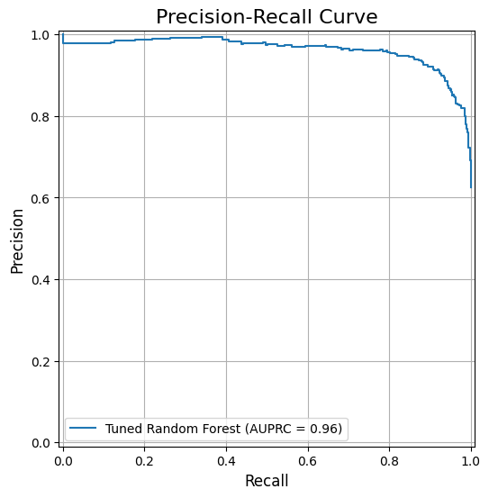

```python
from sklearn.metrics import precision_recall_curve, PrecisionRecallDisplay, auc

# Assuming y_test and y_pred_proba_tuned are already defined

# Calculate precision, recall, and thresholds
precision, recall, _ = precision_recall_curve(y_test, y_pred_proba_tuned)

# Calculate Area Under the Precision-Recall Curve (AUPRC)
auprc = auc(recall, precision)

plt.figure(figsize=(8, 6))
# Plot the Precision-Recall curve
pr_display = PrecisionRecallDisplay(precision=precision, recall=recall, estimator_name='Tuned Random Forest')
pr_display.plot(ax=plt.gca(), name=f'Tuned Random Forest (AUPRC = {auprc:.2f})')

plt.title('Precision-Recall Curve', fontsize=16)
plt.xlabel('Recall', fontsize=12)
plt.ylabel('Precision', fontsize=12)
plt.grid(True)
plt.legend(loc='lower left')
plt.show()
```

**### Comments**

> A high AUPRC (close to 1) indicates that the model has both high precision and high recall, which is desirable, especially in imbalanced datasets where identifying positive cases correctly is crucial.

**### ROC AUC vs. AUPRC for Imbalanced Datasets**

> I have calculated both the ROC AUC (0.9495) and the AUPRC (0.96) for the tuned Random Forest model on the PneumoniaMNIST dataset. While both are powerful metrics for evaluating classification models, they provide different insights, especially in the context of imbalanced datasets.

> **In Summary:** For a medical diagnosis task like Pneumonia detection, where missing a positive case (False Negative) can have serious consequences, and incorrectly diagnosing a healthy patient (False Positive) can lead to unnecessary treatment, **AUPRC often provides a more truthful and direct measure of a model's effectiveness in real-world scenarios, especially when dealing with imbalanced data.**

> The high AUPRC suggests that the tuning strategies have successfully optimized the model for the critical task of accurately identifying Pneumonia.

**## Conclusion: Key Actionable Insights and Recommendations**

> This project successfully developed and evaluated a Random Forest classification model for the PneumoniaMNIST dataset, specifically addressing the challenge of class imbalance. I iterated through several strategies, leading to a robust and interpretable model. Here are the key actionable insights and recommendations:

**### Recommendations for Future Work**

1. **Explore Advanced Deep Learning Models:** Given the image-based nature of the data, Convolutional Neural Networks (CNNs) are likely to yield superior performance. These models can learn hierarchical features directly from raw pixel data, often outperforming traditional machine learning models on complex image tasks. A simple CNN architecture or transfer learning with a pre-trained model could be explored.
2. **Investigate Other Imbalance Techniques:** While undersampling worked well, explore other advanced techniques such as:
   - **Ensemble methods specifically designed for imbalanced learning** (e.g., BalancedBaggingClassifier, EasyEnsembleClassifier, RUSBoostClassifier from `imblearn`).
   - **Different oversampling variations** (e.g., Borderline-SMOTE, ADASYN) or a combination of oversampling and undersampling.
3. **Further Hyperparameter Optimization:** While `RandomizedSearchCV` is efficient, a more focused `GridSearchCV` on a narrower range of the best parameters could potentially eke out marginal improvements.
4. **Consider External Validation:** If possible, test the final model on an entirely independent, unseen dataset from a different source to assess its generalization capabilities beyond the provided PneumoniaMNIST splits.
5. **Clinical Relevance and Thresholding:** Collaborate with medical professionals to define optimal operating points (thresholds) on the ROC or Precision-Recall curve. This will depend on the acceptable trade-off between false positives and false negatives in a real clinical setting.

> This project provides a strong foundation, demonstrating that a carefully tuned Random Forest model with appropriate imbalance handling can achieve excellent performance on the PneumoniaMNIST dataset. The insights gained are valuable for developing similar diagnostic tools.

**## Links**

> GitHub: https://github.com/Saadullahi/HackBio_StageTwo LinkedIn: https://www.linkedin.com/in/sa-ad-abdullahi-3a581296/